# School Leaver Demo Code

This document isn’t intended for standalone use, but you can follow along with the code and watch the live demo from the class.

```r
library(tidyverse)
```

The Scottish school leavers data we discussed in-class.

```r
schools <- read_csv('https://benwhalley.github.io/mixr/data/cmm/5.1.txt')
schools %>% glimpse
```

```
## Rows: 33,988
## Columns: 9
## $ caseid   <dbl> 18, 17, 19, 20, 21, 13, 16, 14, 15, 12, 12865, 6509, 12866, …
## $ schoolid <dbl> 1, 1, 1, 1, 1, 1, 1, 1, 1, 1, 1, 1, 1, 1, 1, 1, 1, 1, 1, 1, …
## $ score    <dbl> 0, 10, 0, 40, 42, 4, 0, 0, 14, 27, 18, 23, 24, 0, 25, 4, 11,…
## $ cohort90 <dbl> -6, -6, -6, -6, -6, -6, -6, -6, -6, -6, -2, -4, -2, -2, -4, …
## $ female   <dbl> 1, 1, 1, 1, 1, 1, 1, 1, 1, 1, 1, 1, 1, 1, 1, 1, 1, 1, 1, 1, …
## $ sclass   <dbl> 2, 2, 4, 3, 2, 2, 3, 4, 3, 2, 2, 1, 2, 3, 2, 3, 2, 4, 3, 3, …
## $ schtype  <dbl> 0, 0, 0, 0, 0, 0, 0, 0, 0, 0, 0, 0, 0, 0, 0, 0, 0, 0, 0, 0, …
## $ schurban <dbl> 1, 1, 1, 1, 1, 1, 1, 1, 1, 1, 1, 1, 1, 1, 1, 1, 1, 1, 1, 1, …
## $ schdenom <dbl> 0, 0, 0, 0, 0, 0, 0, 0, 0, 0, 0, 0, 0, 0, 0, 0, 0, 0, 0, 0, …
```

```r
library(skimr)
skim(schools)
```

Data summary

| Name | schools |
| --- | --- |
| Number of rows | 33988 |
| Number of columns | 9 |
| _______________________ |  |
| Column type frequency: |  |
| numeric | 9 |
| ________________________ |  |
| Group variables | None |

**Variable type: numeric**

| skim_variable | n_missing | complete_rate | mean | sd | p0 | p25 | p50 | p75 | p100 | hist |
| --- | --- | --- | --- | --- | --- | --- | --- | --- | --- | --- |
| caseid | 0 | 1 | 18465.74 | 11435.16 | 1 | 8531.75 | 17318.5 | 29428.25 | 38192 | ▇▇▇▅▇ |
| schoolid | 0 | 1 | 254.36 | 149.76 | 1 | 123.00 | 256.0 | 386.00 | 511 | ▇▇▇▇▇ |
| score | 0 | 1 | 31.09 | 17.31 | 0 | 19.00 | 33.0 | 45.00 | 75 | ▅▆▇▅▁ |
| cohort90 | 0 | 1 | 0.28 | 5.35 | -6 | -4.00 | -2.0 | 6.00 | 8 | ▇▃▃▁▇ |
| female | 0 | 1 | 0.53 | 0.50 | 0 | 0.00 | 1.0 | 1.00 | 1 | ▇▁▁▁▇ |
| sclass | 0 | 1 | 2.15 | 0.99 | 1 | 1.00 | 2.0 | 3.00 | 4 | ▇▇▁▇▂ |
| schtype | 0 | 1 | 0.05 | 0.21 | 0 | 0.00 | 0.0 | 0.00 | 1 | ▇▁▁▁▁ |
| schurban | 0 | 1 | 0.71 | 0.45 | 0 | 0.00 | 1.0 | 1.00 | 1 | ▃▁▁▁▇ |
| schdenom | 0 | 1 | 0.16 | 0.36 | 0 | 0.00 | 0.0 | 0.00 | 1 | ▇▁▁▁▂ |

# Exploring the data

## What is the overall distribution of scores?

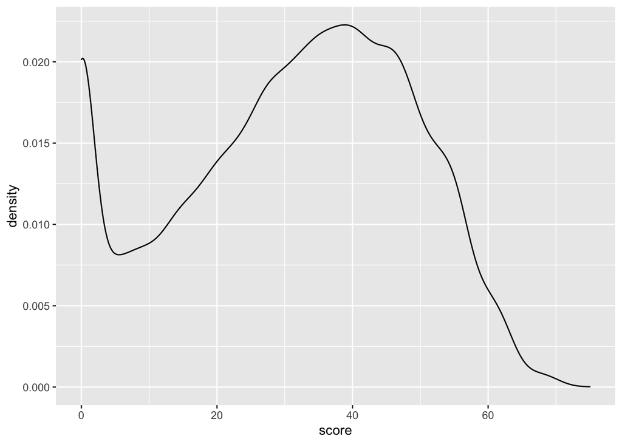

```r
schools %>% ggplot(aes(score)) +
  geom_density()
```

## Do types of schools differ?

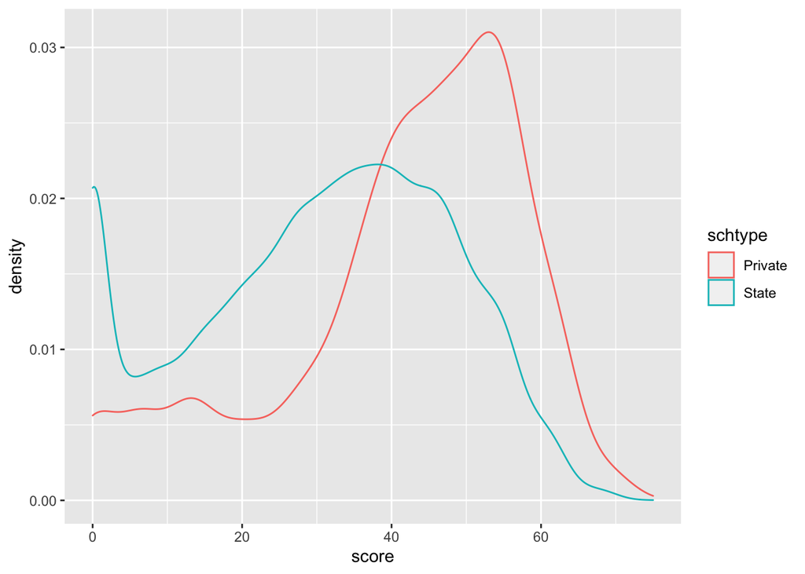

```r
schools$schtype <- recode(schools$schtype, `0`="State", `1`="Private")

schools %>% ggplot(aes(score, color=schtype)) +
  geom_density()
```

## Do urban and rural schools differ?

Perhaps a bit:

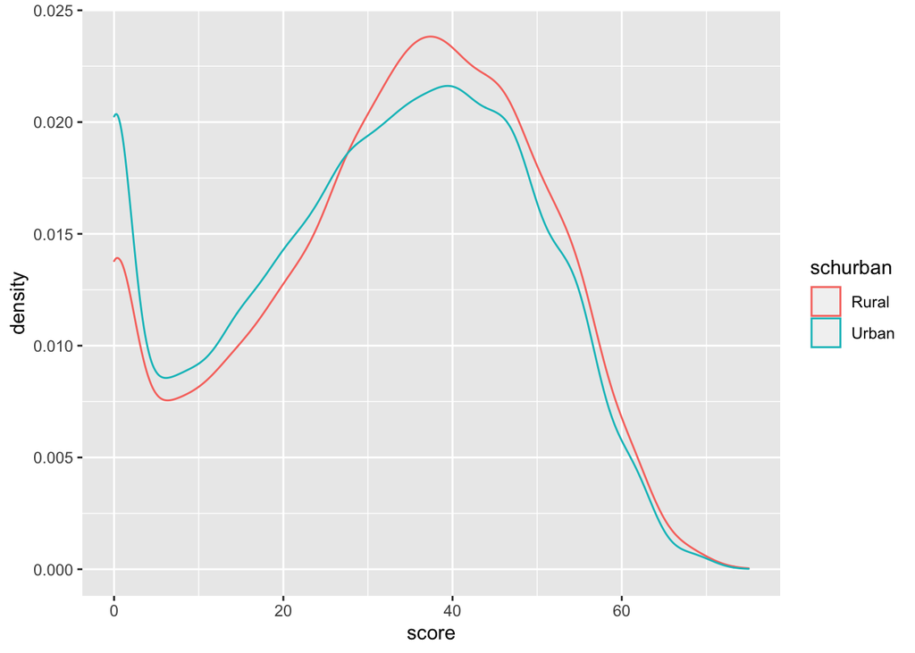

```r
schools$schurban <- recode(schools$schurban, `0`="Rural", `1`="Urban")

schools %>% ggplot(aes(score, color=schurban)) +
  geom_density()
```

# Is there an interaction between location and type?

Probably…

```
## No summary function supplied, defaulting to `mean_se()`
```

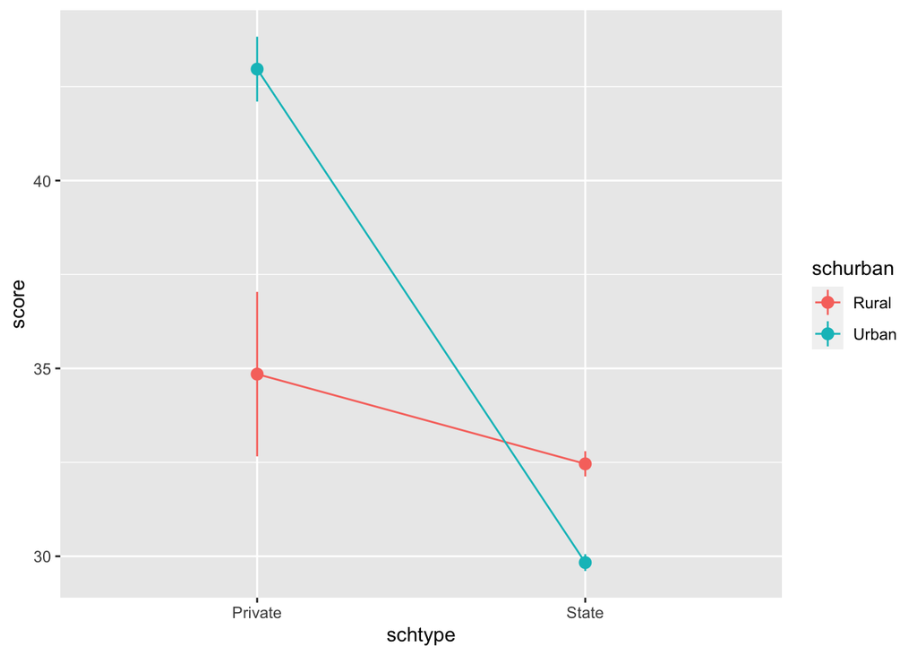

```r
schools %>%
  ggplot(aes(schtype, score, color=schurban, group=schurban)) +
  stat_summary(fun.data=mean_cl_normal) +
  stat_summary(geom="line")
```

# Questions we might want to ask

- How much *variability* is there between schools?
- What is the difference in scores between a high performing and low-performing school?
- Is the variation between schools explainable? (e.g. rural/urban or state/private)?

## How much variability is there between schools?

This is just a sample of the data — there are too many schools to plot:

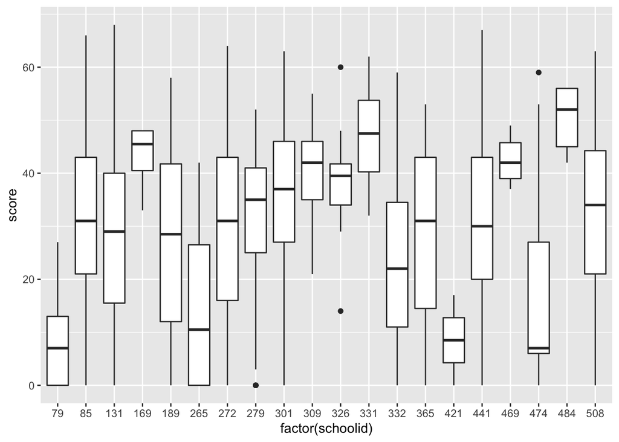

```r
set.seed(1)
schools %>%
  # head(1000) %>%
  filter(schoolid %in% sample(unique(schoolid), 20)) %>%
  ggplot(aes(factor(schoolid), score)) + geom_boxplot()
```

Another way of looking at variability between schools: we aggregate scores by-school:

```r
schools.agg <- schools %>%
  group_by(schoolid) %>%
  mutate(score = mean(score))
```

And then plot them:

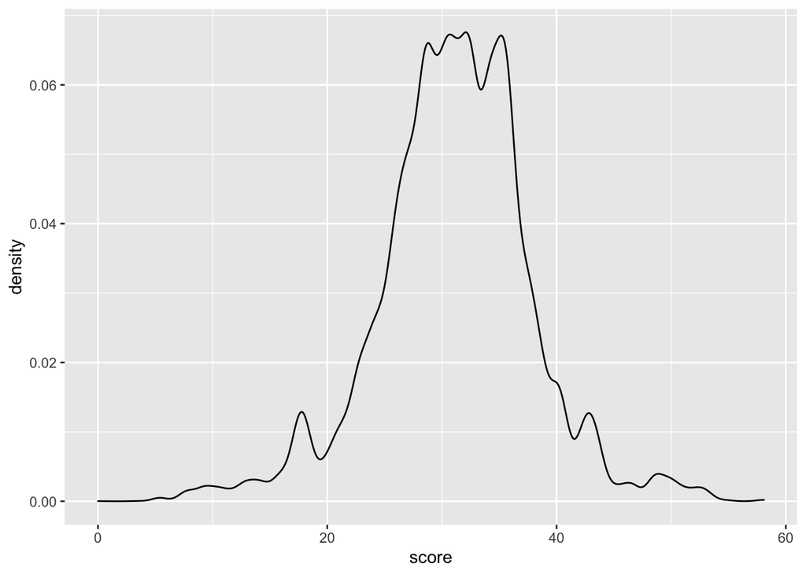

```r
schools.agg %>%
  ggplot(aes(score)) +
  geom_density()
```

# What’s the difference in scores between the best and worst schools?

The min/max might be edge cases, so let’s look at the quantiles:

```r
(score.quants <- quantile(schools.agg$score, probs = c(0.05, .25,.5,.75, .95)))
```

```
##       5%      25%      50%      75%      95%
## 18.55224 27.27273 31.26786 35.16185 42.10000
```

To be fancy we could add these lines to our plot:

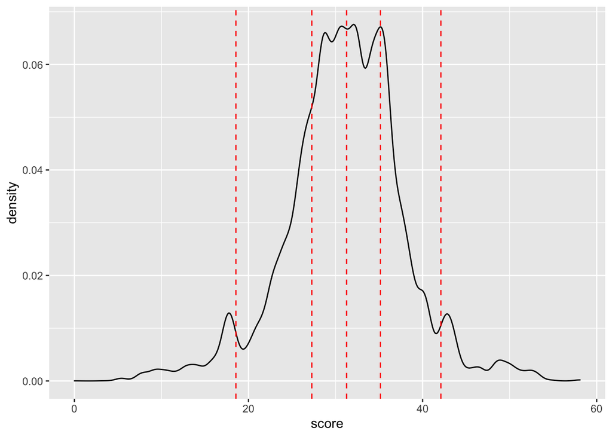

```r
schools.agg %>%
  ggplot(aes(score)) +
  geom_density() +
  geom_vline(data=tibble(q=score.quants),
             aes(xintercept=q), color="red", linetype="dashed")
```

# Is the variation between schools explainable?

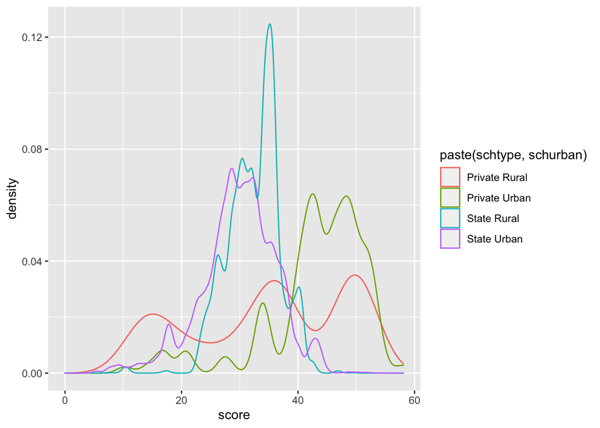

```r
schools.agg %>%
  ggplot(aes(score, color=paste(schtype, schurban))) +
  geom_density()
```

We could run a model on the aggregated data:

```r
lm.schools.agg <- lm( score ~ schurban * schtype, data=schools.agg)
anova(lm.schools.agg)
```

```
## Analysis of Variance Table
##
## Response: score
##                     Df  Sum Sq Mean Sq F value    Pr(>F)
## schurban             1   28815   28815  746.20 < 2.2e-16 ***
## schtype              1  176789  176789 4578.22 < 2.2e-16 ***
## schurban:schtype     1   27192   27192  704.17 < 2.2e-16 ***
## Residuals        33984 1312301      39
## ---
## Signif. codes:  0 '***' 0.001 '**' 0.01 '*' 0.05 '.' 0.1 ' ' 1
```

BUT… what about this plot?

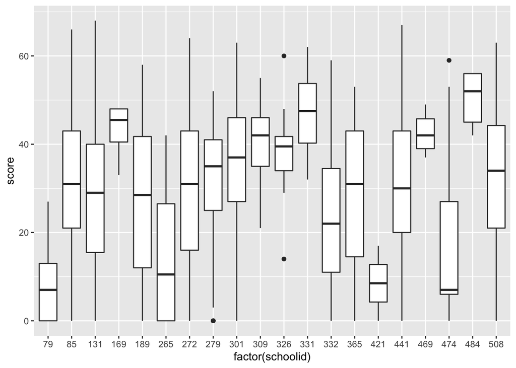

```r
set.seed(1)
schools %>%
  filter(schoolid %in% sample(unique(schoolid), 20)) %>%
  ggplot(aes(factor(schoolid), score)) + geom_boxplot()
```

We saw from this plot that some schools had much less variance than others.

Lower variance == Better estimate of the school mean. We want to acknowledge that in our estimates.

-> We need to run a model on the RAW data, but which *partitions* the variance within an between schools.

This model will **allow for the fact that we know MORE about some schools than others**.

# Running a model with `lmer`

This model uses the raw data, splitting the variance within and between schools. It includes the same predictors as before:

```r
library(lmerTest)
lmer.schools <- lmer(score ~ schurban * schtype + (1|schoolid), data=schools)

anova(lmer.schools)
```

```
## Type III Analysis of Variance Table with Satterthwaite's method
##                  Sum Sq Mean Sq NumDF  DenDF F value    Pr(>F)
## schurban          264.1   264.1     1 541.15  1.0221    0.3125
## schtype          7821.3  7821.3     1 541.15 30.2669 5.816e-08 ***
## schurban:schtype 4143.0  4143.0     1 541.15 16.0325 7.096e-05 ***
## ---
## Signif. codes:  0 '***' 0.001 '**' 0.01 '*' 0.05 '.' 0.1 ' ' 1
```

This is often the case: aggregating data will TEND to increase type 1 errors. However, allowing for within-unit variance can go both ways:

Accounting for the PRECISION with which we estimate schools can help us too.

Intuitively this makes sense: If a small school (small N) had an ‘odd’ result due to sampling error it would be over-weighted when we aggregate the scores.

The aggregation throws away data about how CONFIDENT we were in each individual school’s mean.

By allowing for within-school variance we can quantify our uncertainty more accurately and make better inferences.

## How much variation was between schools, and how much within?

The `VarCorr` function summarises variances at each level.

First though, let’s run a model without any predictors as a baseline:

```r
lmer.schools.interceptonly <- lmer(score ~  1 + (1|schoolid), data=schools)
```

```r
lmer.schools.interceptonly %>% VarCorr()
```

```
##  Groups   Name        Std.Dev.
##  schoolid (Intercept)  7.8213
##  Residual             16.0735
```

## Calculating VPC

If you convert the output to a data-frame you also get the *variances* which is helpful:

```r
lmer.schools.interceptonly %>% VarCorr() %>% as_data_frame()
```

```
## # A tibble: 2 x 5
##   grp      var1        var2   vcov sdcor
##   <chr>    <chr>       <chr> <dbl> <dbl>
## 1 schoolid (Intercept) <NA>   61.2  7.82
## 2 Residual <NA>        <NA>  258.  16.1
```

Note - you can only calculate the VPC with VARIANCES, not with standard deviations.

We can calculate the variance partition coefficient (proportion of variance) like this:

```r
library(pander)
lmer.schools.interceptonly %>% VarCorr() %>% as_data_frame() %>%
  mutate(vpc = vcov/sum(vcov)) %>%
  pander()
```

| grp | var1 | var2 | vcov | sdcor | vpc |
| --- | --- | --- | --- | --- | --- |
| schoolid | (Intercept) | NA | 61.17 | 7.821 | 0.1914 |
| Residual | NA | NA | 258.4 | 16.07 | 0.8086 |

The variation between schools is 19% So the variation *within* schools is 81%. This is the UNEXPLAINED variation in this model.

But can we explain it? Let’s compare to our model *with* the predictors?

```r
lmer.schools %>% VarCorr() %>% as_data_frame() %>%
  mutate(vpc = vcov/sum(vcov)) %>%
  pander()
```

| grp | var1 | var2 | vcov | sdcor | vpc |
| --- | --- | --- | --- | --- | --- |
| schoolid | (Intercept) | NA | 48.35 | 6.953 | 0.1576 |
| Residual | NA | NA | 258.4 | 16.08 | 0.8424 |

This is an aside, and you don’t need to do this, but because I’m going to calculate VPC often I might write my own function to simplify ny code:

```r
# my function takes an lmer model as in put, and returns a data frame with variances and vpcs
vpc <- function(lmerModel) {
  lmerModel %>%
    VarCorr() %>%
    as_data_frame() %>%
    mutate(vpc = vcov/sum(vcov) * 100, 1) %>%
    select(Group=grp, var1, var2, vcov, vpc)
}

lmer.schools %>% vpc %>% pander()
```

| Group | var1 | var2 | vcov | vpc |
| --- | --- | --- | --- | --- |
| schoolid | (Intercept) | NA | 48.35 | 15.76 |
| Residual | NA | NA | 258.4 | 84.24 |

## Some of the variance could be explained!

After including the predictors only 16% of variance is between schools, and 84% within.

We could run further models including more predictors, since we have them:

```r
lmer.schools.everything <- lmer(score ~  schtype*schurban + female + factor(cohort90) + (1|schoolid), data=schools)

lmer.schools.everything %>% vpc %>% pander()
```

| Group | var1 | var2 | vcov | vpc |
| --- | --- | --- | --- | --- |
| schoolid | (Intercept) | NA | 36.3 | 14.3 |
| Residual | NA | NA | 217.7 | 85.7 |

And now we’re down to 14% for between-school variance.

## Why does this matter?

Remember — the between school variation is important here because it represents the differences between the best and worst schools. If you were a teacher or pupil in these schools you would care about this!

## A twist at the end…

But… the thing we’ve been missing is that there is actually ANOTHER level of nesting in these data: your school class.

Classes are nested within schools:

Here the `/` denotes nesting of `sclass` within `schoolid`.

```r
lmer.schools.classes <- lmer(score ~  1 + (1| schoolid / sclass), data=schools)

lmer.schools.classes %>%  vpc %>% pander()
```

| Group | var1 | var2 | vcov | vpc |
| --- | --- | --- | --- | --- |
| sclass:schoolid | (Intercept) | NA | 42.72 | 13.81 |
| schoolid | (Intercept) | NA | 35.84 | 11.59 |
| Residual | NA | NA | 230.7 | 74.6 |

Now the school variance goes down a bit (only 11.5%), but the unexplained variance (within schools) does down a lot.

Now, we can see 14% of the variance is attributed to school *classes*.

We might want to categorise this as a “teacher effect”

# What have we learned?

- We can explain some of the variance by school location and type
- Quite a bit of the variance was still unexplained
- Adding additional levels of ‘nesting’ can help explain: teachers matter more than schools!

Also

- Aggregating data throws away information
- This *can* affect inferences for predictors (like school location etc)
- We miss opportunities to explore and understand the variation in our data

# Testing variances

If the VPC was quite small we migth want to ask whether a particular level of nesting explained ‘significant’ variation in the outcome.

Remembering that statistically significant != important, we can use NHST on variances in these models:

```r
lmer.schools.classes %>% ranova()
```

```
## ANOVA-like table for random-effects: Single term deletions
##
## Model:
## score ~ (1 | sclass:schoolid) + (1 | schoolid)
##                       npar  logLik    AIC     LRT Df Pr(>Chisq)
## <none>                   4 -142172 284353
## (1 | sclass:schoolid)    3 -143270 286545 2194.49  1  < 2.2e-16 ***
## (1 | schoolid)           3 -142272 284550  199.18  1  < 2.2e-16 ***
## ---
## Signif. codes:  0 '***' 0.001 '**' 0.01 '*' 0.05 '.' 0.1 ' ' 1
```

The `ranova` table tell us that classes and schools explain variance in outcomes, and this isn’t due to chance.